# AR-MA Manual

Dewi Kunthi Siswati Suryo

2023-09-21

## Nomor (1) MA(2)

# White Nose

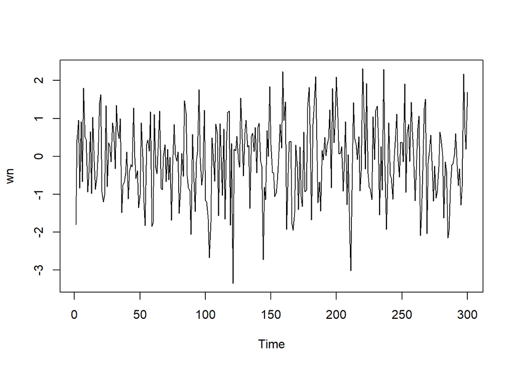

```r
set.seed(1017)
wn <- rnorm(300)
ts.plot(wn)
```

Dapat terlihat bahwa *white noise* tidak memiliki autokorelasi dari ACF. Perhatikan bahwa lag ke-0 adalah korelasi observasi ke-t dengan dirinya sendiri. Nilai korelasi tersebut pasti 1. Sebagai alternatif, lag pertama di plot ACF dapat ditetapkan sebagai 1 (alih-alih 0) dengan menambahkan argumen `xlim(1, lag akhir)`. Plot tersebut dapat disandingkan bersamaan dengan membuat matriks $1 \times 2$ dengan `par(mfrow = c(1,2))`.

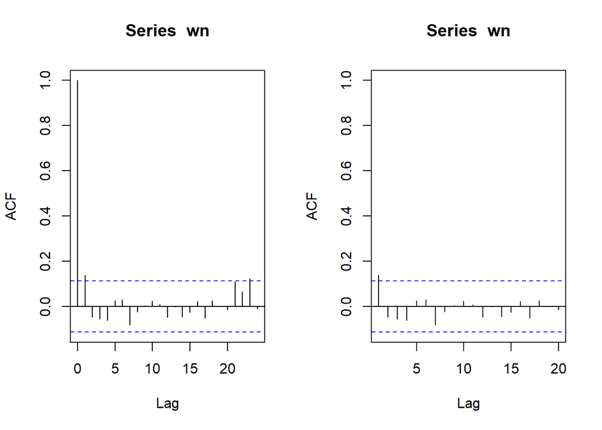

```r
par(mfrow = c(1, 2))
acf(wn)
acf(wn, xlim = c(1, 20))
```

# Pembangkitan Proses MA(2)

```r
set.seed(1017)
ma <- wn[1]
ma[2] <- wn[2]
```

Nilai-nilai selanjutnya dapat dicari melalui *loop*. Bentuk loop dapat dilihat dari rumus MA(2) yang hendak dibangkitkan:

$$y_t = e_t+0.4e_{t-1}+0.6e_{t-2}$$

```r
for(i in 3:300){
   ma[i] <- wn[i] + 0.4 * wn[i - 1] + 0.6 * wn[i-2]
}
ma
```

```
##   [1] -1.803280424  0.442706287  0.051907638 -0.190457994  1.152192106
##   [6] -0.812776398  2.083395853  0.828742695  1.723384316 -0.458120868
##  [11] -0.555371259 -0.087390024 -0.991359214  1.031730557 -0.316578294
##  [16] -0.308583571 -0.971560252 -0.717203949  1.093917295  2.212611623
##  [21]  0.561693955 -0.595880864 -2.080851708  0.204113888 -0.891014299
##  [26]  0.845071167 -0.077408623  0.174789391  0.984222553  0.921166222
##  [31]  0.462425674  1.608564724  1.032679787  1.558288519  1.602656055
##  [36] -0.806284982 -0.758290286 -1.869988493 -1.177799176 -0.471391252
##  [41] -1.350769961 -0.790362949 -1.057901931 -0.613596539  1.032154262
##  [46]  0.304013881  0.165402475 -0.639103765 -1.857482512 -1.783282922
##  [51] -0.328789796 -0.253514641 -0.678762977 -2.318243872 -1.143041193
##  [56] -0.538774236  0.501959588  1.488393678 -1.295957806 -1.789153929
##  [61] -0.706224593 -0.921180809  0.080043601  0.083685871  1.105643028
##  [66] -0.091544923 -0.496743389 -0.840326224 -0.216790440 -0.541949144
##  [71]  0.095616282 -0.951882412 -0.161192318 -2.068099700 -0.919193934
```

[output cut: 45 more lines]

```r
ma2 <- arima.sim(list(order=c(0,0,2), ma=c(0.4, 0.6)), n=300)
ma2
```

```
## Time Series:
## Start = 1
## End = 300
## Frequency = 1
##   [1]  0.051907638 -0.190457994  1.152192106 -0.812776398  2.083395853
##   [6]  0.828742695  1.723384316 -0.458120868 -0.555371259 -0.087390024
##  [11] -0.991359214  1.031730557 -0.316578294 -0.308583571 -0.971560252
##  [16] -0.717203949  1.093917295  2.212611623  0.561693955 -0.595880864
##  [21] -2.080851708  0.204113888 -0.891014299  0.845071167 -0.077408623
##  [26]  0.174789391  0.984222553  0.921166222  0.462425674  1.608564724
##  [31]  1.032679787  1.558288519  1.602656055 -0.806284982 -0.758290286
##  [36] -1.869988493 -1.177799176 -0.471391252 -1.350769961 -0.790362949
##  [41] -1.057901931 -0.613596539  1.032154262  0.304013881  0.165402475
##  [46] -0.639103765 -1.857482512 -1.783282922 -0.328789796 -0.253514641
##  [51] -0.678762977 -2.318243872 -1.143041193 -0.538774236  0.501959588
```

[output cut: 49 more lines]

# Karakteristik MA(2)

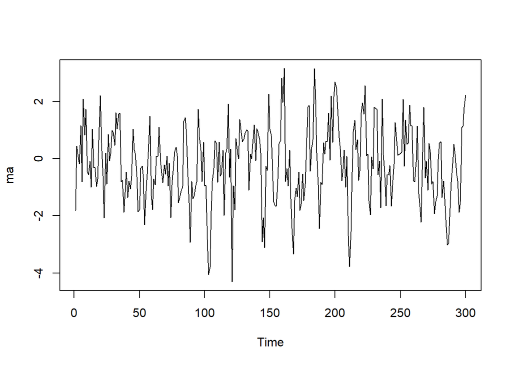

```r
ts.plot(ma)
```

Berdasarkan plot time series, terlihat bahwa data MA(2) yang dibangkitkan stasioner dalam rataan

# Plot ACF

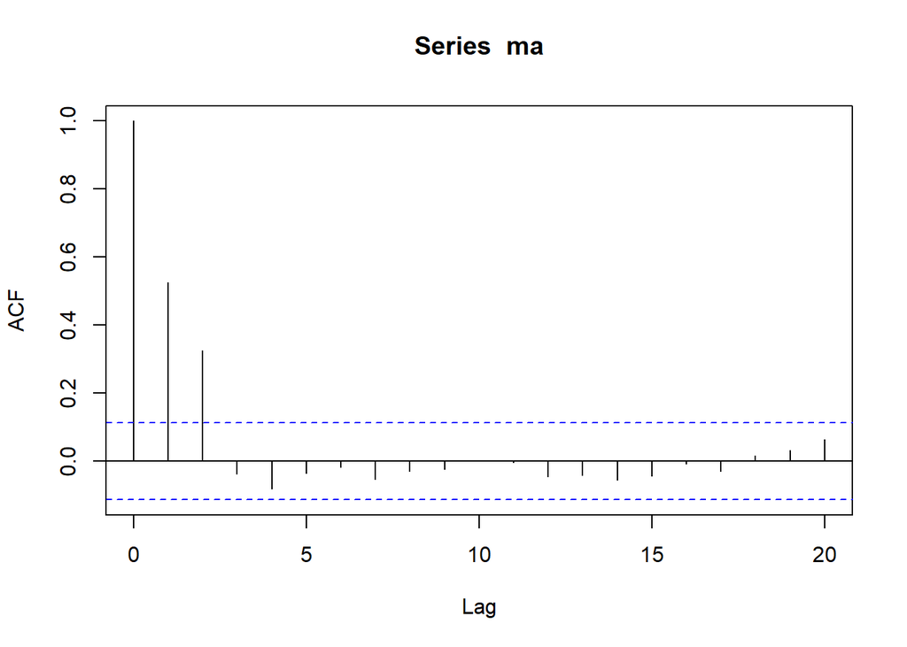

```r
acf(ma,lag.max = 20)
```

Berdasarkan plot AFC tersebut, terlihat bahwa plot ACF *cuts off* di lag kedua.

# Plot PACF

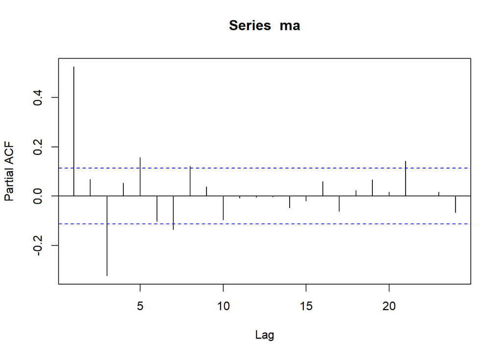

```r
pacf(ma)
```

Berdasarkan plot PACF tersebut, terlihat bahwa plot PACF cenderung *tails off* dan membentuk gelombang sinus

# Plot EACF

```r
TSA::eacf(ma)
```

```
## AR/MA
##   0 1 2 3 4 5 6 7 8 9 10 11 12 13
## 0 x x o o o o o o o o o  o  o  o
## 1 x x x o o o o o o o o  o  o  o
## 2 x x x o o o o o o o o  o  o  o
## 3 x x x o x o o o o o o  o  o  o
## 4 x x x x x o o o o o o  o  o  o
## 5 x x o x x o x o o o o  o  o  o
## 6 x x x x x o x o o o o  o  o  o
## 7 x x o x o o x x x o o  o  o  o
```

Berdasarkan pola segitiga nol pada plot EACF, terlihat bahwa segitiga nol berada pada ordo AR(0) dan ordo MA(2)

# Scatterplot Antar Lag

## Korelasi antara $Y_t$ dengan $Y_{t-1}$

```r
#Yt
yt_ma <- ma[-1]
yt_ma
```

```
##   [1]  0.442706287  0.051907638 -0.190457994  1.152192106 -0.812776398
##   [6]  2.083395853  0.828742695  1.723384316 -0.458120868 -0.555371259
##  [11] -0.087390024 -0.991359214  1.031730557 -0.316578294 -0.308583571
##  [16] -0.971560252 -0.717203949  1.093917295  2.212611623  0.561693955
##  [21] -0.595880864 -2.080851708  0.204113888 -0.891014299  0.845071167
##  [26] -0.077408623  0.174789391  0.984222553  0.921166222  0.462425674
##  [31]  1.608564724  1.032679787  1.558288519  1.602656055 -0.806284982
##  [36] -0.758290286 -1.869988493 -1.177799176 -0.471391252 -1.350769961
##  [41] -0.790362949 -1.057901931 -0.613596539  1.032154262  0.304013881
##  [46]  0.165402475 -0.639103765 -1.857482512 -1.783282922 -0.328789796
##  [51] -0.253514641 -0.678762977 -2.318243872 -1.143041193 -0.538774236
##  [56]  0.501959588  1.488393678 -1.295957806 -1.789153929 -0.706224593
##  [61] -0.921180809  0.080043601  0.083685871  1.105643028 -0.091544923
##  [66] -0.496743389 -0.840326224 -0.216790440 -0.541949144  0.095616282
##  [71] -0.951882412 -0.161192318 -2.068099700 -0.919193934 -0.255637024
```

[output cut: 45 more lines]

```r
#Yt-1
yt_1_ma <- ma[-300]
yt_1_ma
```

```
##   [1] -1.803280424  0.442706287  0.051907638 -0.190457994  1.152192106
##   [6] -0.812776398  2.083395853  0.828742695  1.723384316 -0.458120868
##  [11] -0.555371259 -0.087390024 -0.991359214  1.031730557 -0.316578294
##  [16] -0.308583571 -0.971560252 -0.717203949  1.093917295  2.212611623
##  [21]  0.561693955 -0.595880864 -2.080851708  0.204113888 -0.891014299
##  [26]  0.845071167 -0.077408623  0.174789391  0.984222553  0.921166222
##  [31]  0.462425674  1.608564724  1.032679787  1.558288519  1.602656055
##  [36] -0.806284982 -0.758290286 -1.869988493 -1.177799176 -0.471391252
##  [41] -1.350769961 -0.790362949 -1.057901931 -0.613596539  1.032154262
##  [46]  0.304013881  0.165402475 -0.639103765 -1.857482512 -1.783282922
##  [51] -0.328789796 -0.253514641 -0.678762977 -2.318243872 -1.143041193
##  [56] -0.538774236  0.501959588  1.488393678 -1.295957806 -1.789153929
##  [61] -0.706224593 -0.921180809  0.080043601  0.083685871  1.105643028
##  [66] -0.091544923 -0.496743389 -0.840326224 -0.216790440 -0.541949144
##  [71]  0.095616282 -0.951882412 -0.161192318 -2.068099700 -0.919193934
```

[output cut: 45 more lines]

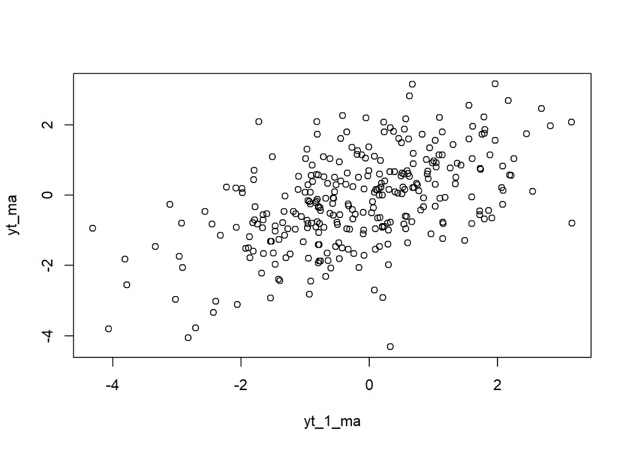

```r
plot(y=yt_ma,x=yt_1_ma)
```

Berdasarkan scatterplot tersebut, terlihat bahwa terdapat hubungan positif antara $Y_t$ dengan $Y_{t-1}$. Hal ini sesuai dengan teori yang ada

## Korelasi antara $Y_t$ dengan $Y_{t-2}$

```r
#Yt
yt_ma2 <- ma[-c(1,2)]
yt_ma2
```

```
##   [1]  0.051907638 -0.190457994  1.152192106 -0.812776398  2.083395853
##   [6]  0.828742695  1.723384316 -0.458120868 -0.555371259 -0.087390024
##  [11] -0.991359214  1.031730557 -0.316578294 -0.308583571 -0.971560252
##  [16] -0.717203949  1.093917295  2.212611623  0.561693955 -0.595880864
##  [21] -2.080851708  0.204113888 -0.891014299  0.845071167 -0.077408623
##  [26]  0.174789391  0.984222553  0.921166222  0.462425674  1.608564724
##  [31]  1.032679787  1.558288519  1.602656055 -0.806284982 -0.758290286
##  [36] -1.869988493 -1.177799176 -0.471391252 -1.350769961 -0.790362949
##  [41] -1.057901931 -0.613596539  1.032154262  0.304013881  0.165402475
##  [46] -0.639103765 -1.857482512 -1.783282922 -0.328789796 -0.253514641
##  [51] -0.678762977 -2.318243872 -1.143041193 -0.538774236  0.501959588
##  [56]  1.488393678 -1.295957806 -1.789153929 -0.706224593 -0.921180809
##  [61]  0.080043601  0.083685871  1.105643028 -0.091544923 -0.496743389
##  [66] -0.840326224 -0.216790440 -0.541949144  0.095616282 -0.951882412
##  [71] -0.161192318 -2.068099700 -0.919193934 -0.255637024  0.239684777
```

[output cut: 45 more lines]

```r
#Yt-2
yt_2_ma <- ma[-c(299,300)]
yt_2_ma
```

```
##   [1] -1.803280424  0.442706287  0.051907638 -0.190457994  1.152192106
##   [6] -0.812776398  2.083395853  0.828742695  1.723384316 -0.458120868
##  [11] -0.555371259 -0.087390024 -0.991359214  1.031730557 -0.316578294
##  [16] -0.308583571 -0.971560252 -0.717203949  1.093917295  2.212611623
##  [21]  0.561693955 -0.595880864 -2.080851708  0.204113888 -0.891014299
##  [26]  0.845071167 -0.077408623  0.174789391  0.984222553  0.921166222
##  [31]  0.462425674  1.608564724  1.032679787  1.558288519  1.602656055
##  [36] -0.806284982 -0.758290286 -1.869988493 -1.177799176 -0.471391252
##  [41] -1.350769961 -0.790362949 -1.057901931 -0.613596539  1.032154262
##  [46]  0.304013881  0.165402475 -0.639103765 -1.857482512 -1.783282922
##  [51] -0.328789796 -0.253514641 -0.678762977 -2.318243872 -1.143041193
##  [56] -0.538774236  0.501959588  1.488393678 -1.295957806 -1.789153929
##  [61] -0.706224593 -0.921180809  0.080043601  0.083685871  1.105643028
##  [66] -0.091544923 -0.496743389 -0.840326224 -0.216790440 -0.541949144
##  [71]  0.095616282 -0.951882412 -0.161192318 -2.068099700 -0.919193934
```

[output cut: 45 more lines]

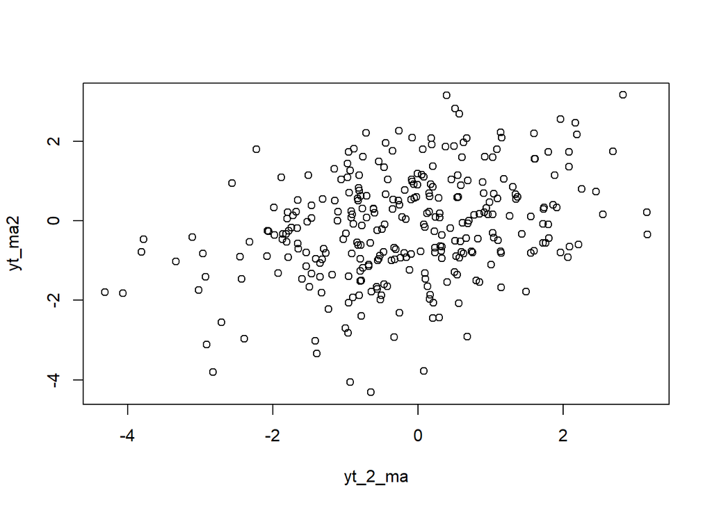

```r
plot(y=yt_ma2,x=yt_2_ma)
```

## Korelasi antara $Y_t$ dengan $Y_{t-3}$

```r
#Yt
yt_ma3 <- ma[-c(1,2,3)]
yt_ma3
```

```
##   [1] -0.190457994  1.152192106 -0.812776398  2.083395853  0.828742695
##   [6]  1.723384316 -0.458120868 -0.555371259 -0.087390024 -0.991359214
##  [11]  1.031730557 -0.316578294 -0.308583571 -0.971560252 -0.717203949
##  [16]  1.093917295  2.212611623  0.561693955 -0.595880864 -2.080851708
##  [21]  0.204113888 -0.891014299  0.845071167 -0.077408623  0.174789391
##  [26]  0.984222553  0.921166222  0.462425674  1.608564724  1.032679787
##  [31]  1.558288519  1.602656055 -0.806284982 -0.758290286 -1.869988493
##  [36] -1.177799176 -0.471391252 -1.350769961 -0.790362949 -1.057901931
##  [41] -0.613596539  1.032154262  0.304013881  0.165402475 -0.639103765
##  [46] -1.857482512 -1.783282922 -0.328789796 -0.253514641 -0.678762977
##  [51] -2.318243872 -1.143041193 -0.538774236  0.501959588  1.488393678
##  [56] -1.295957806 -1.789153929 -0.706224593 -0.921180809  0.080043601
##  [61]  0.083685871  1.105643028 -0.091544923 -0.496743389 -0.840326224
##  [66] -0.216790440 -0.541949144  0.095616282 -0.951882412 -0.161192318
##  [71] -2.068099700 -0.919193934 -0.255637024  0.239684777  0.403902978
```

[output cut: 45 more lines]

```r
#Yt-3
yt_3_ma <- ma[-c(298,299,300)]
yt_3_ma
```

```
##   [1] -1.803280424  0.442706287  0.051907638 -0.190457994  1.152192106
##   [6] -0.812776398  2.083395853  0.828742695  1.723384316 -0.458120868
##  [11] -0.555371259 -0.087390024 -0.991359214  1.031730557 -0.316578294
##  [16] -0.308583571 -0.971560252 -0.717203949  1.093917295  2.212611623
##  [21]  0.561693955 -0.595880864 -2.080851708  0.204113888 -0.891014299
##  [26]  0.845071167 -0.077408623  0.174789391  0.984222553  0.921166222
##  [31]  0.462425674  1.608564724  1.032679787  1.558288519  1.602656055
##  [36] -0.806284982 -0.758290286 -1.869988493 -1.177799176 -0.471391252
##  [41] -1.350769961 -0.790362949 -1.057901931 -0.613596539  1.032154262
##  [46]  0.304013881  0.165402475 -0.639103765 -1.857482512 -1.783282922
##  [51] -0.328789796 -0.253514641 -0.678762977 -2.318243872 -1.143041193
##  [56] -0.538774236  0.501959588  1.488393678 -1.295957806 -1.789153929
##  [61] -0.706224593 -0.921180809  0.080043601  0.083685871  1.105643028
##  [66] -0.091544923 -0.496743389 -0.840326224 -0.216790440 -0.541949144
##  [71]  0.095616282 -0.951882412 -0.161192318 -2.068099700 -0.919193934
```

[output cut: 45 more lines]

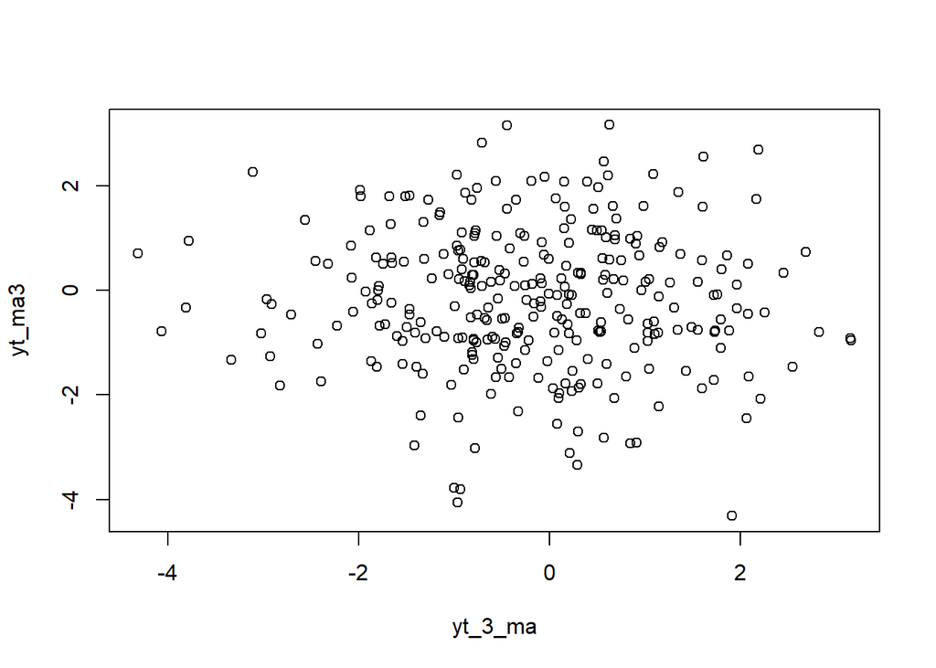

```r
plot(y=yt_ma3,x=yt_3_ma)
```

Berdasarkan scatterplot tersebut, terlihat bahwa cenderung tidak terdapat hubungan antara $Y_t$ dengan $Y_{t-3}$.

```r
cor(yt_ma,yt_1_ma)
```

```
## [1] 0.5288501
```

```r
cor(yt_ma2,yt_2_ma)
```

```
## [1] 0.3290686
```

```r
cor(yt_ma3,yt_3_ma)
```

```
## [1] -0.03841713
```

## Nomor (2) AR(2)

# Pembangkitan Proses AR

Akan dicoba membangkitkan proses AR paling sederhana, yaitu AR(2) dengan $\phi = 0.5$ dan $\phi = 0.2$ sebanyak 300 observasi dan $c=0$.

```r
set.seed(1017)
```

Nilai-nilai selanjutnya dapat dicari melalui *loop*. Bentuk loop dapat dilihat dari rumus AR(2) yang hendak dibangkitkan:

$$Y_t = e_t+0.5Y_{t-1}+0.2Y_{t-2}$$

```r
n<-length(wn)
n
```

```
## [1] 300
```

```r
ar <- c(1:n)
for(i in 3:n){
  ar[i] <- wn[i]+0.5*ar[i-1]+0.2*ar[i-2]
}
ar
```

```
##   [1]  1.000000000  2.000000000  2.156793378  0.639597572  1.664793187
##   [6]  0.285364890  2.280835987  1.709126435  1.746343603  0.275649667
##  [11]  0.046093350  0.730795119 -0.613190266  0.874845940  0.176777701
##  [16] -0.611191876 -0.809176354 -0.503726170  0.994340360  2.031960854
##  [21]  0.277504861 -0.657120352 -1.310598748  0.553765233 -0.789923176
##  [26]  0.078443836  0.141579335 -0.060460421  0.884878521  1.084959566
##  [31]  0.387960487  1.759367447  1.649494492  1.648984611  2.152770506
##  [36] -0.082872853 -0.372578181 -0.874740794 -0.963916843 -0.544359229
##  [41] -1.589533399 -1.311701739 -1.193691953 -1.139971186  0.467704865
##  [46] -0.032228547 -0.507793438 -0.642506093 -1.776296697 -2.029240305
##  [51] -0.481542016 -0.647914257 -1.631512919 -2.778307115 -1.398561780
##  [56] -0.820693612 -0.551935671  0.732488503 -1.592012808 -2.403071699
##  [61] -0.416015850 -0.999234301 -1.040885441 -0.267010440  0.857488135
##  [66] -0.467838606 -0.941395097 -0.547093774 -0.158100892 -0.862211248
##  [71] -0.279847710 -0.933154525 -0.545150610 -2.145791335 -1.412923390
```

[output cut: 45 more lines]

```r
ar2 <- arima.sim(list(order=c(2,0,0), ar=c(0.5, 0.2)), n=300)
ar2
```

```
## Time Series:
## Start = 1
## End = 300
## Frequency = 1
##   [1]  0.074915132  0.138889236 -0.062511212  0.883315106  1.083767700
##   [6]  0.387051871  1.758674766  1.648966429  1.648582043  2.152463610
##  [11] -0.083106815 -0.372756541 -0.874876767 -0.964020501 -0.544438252
##  [16] -1.589593643 -1.311747666 -1.193726965 -1.139997877  0.467684517
##  [21] -0.032244059 -0.507805264 -0.642515109 -1.776303570 -2.029245545
##  [26] -0.481546010 -0.647917302 -1.631515241 -2.778308885 -1.398563129
##  [31] -0.820694640 -0.551936455  0.732487905 -1.592013263 -2.403072046
##  [36] -0.416016115 -0.999234503 -1.040885595 -0.267010558  0.857488046
##  [41] -0.467838674 -0.941395149 -0.547093814 -0.158100922 -0.862211271
##  [46] -0.279847728 -0.933154538 -0.545150620 -2.145791343 -1.412923396
##  [51] -0.286906875 -0.387240016 -0.371845501 -0.145281057 -1.658912497
```

[output cut: 49 more lines]

# Karakteristik AR(2)

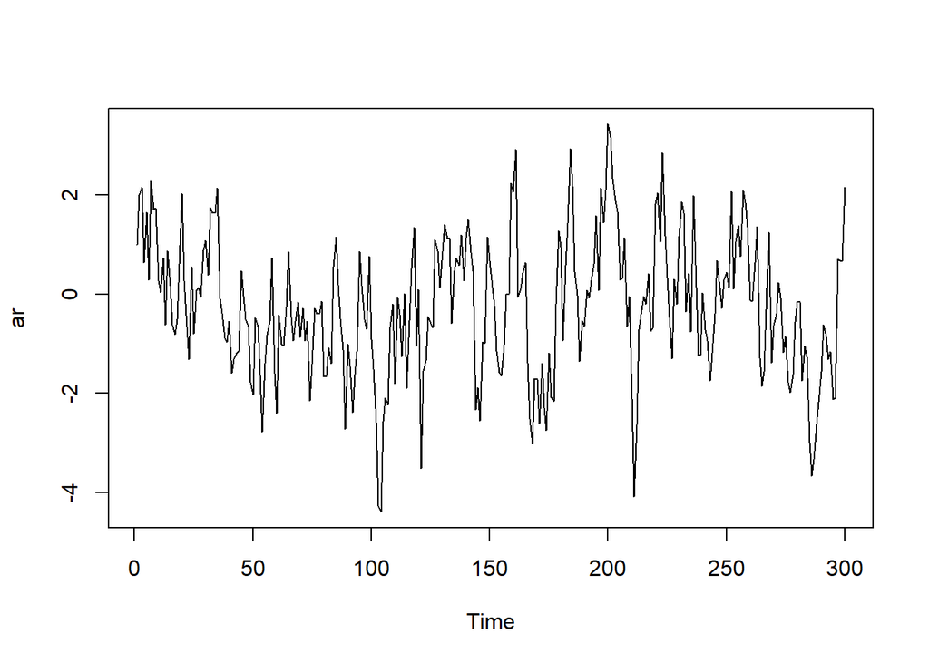

```r
# Plot Time Series
ts.plot(ar)
```

Berdasarkan plot time series tersebut terlihat bahwa data cenderung stasioner pada rataan

# Plot ACF

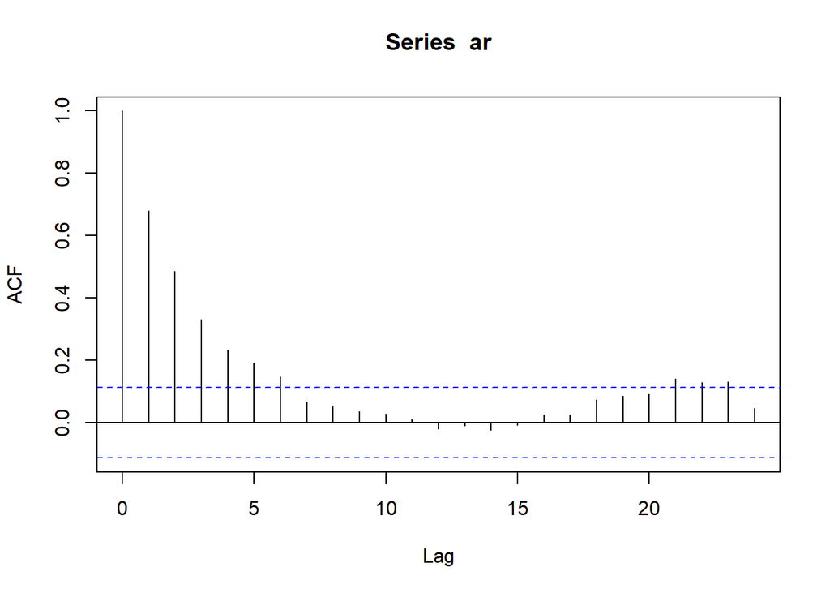

```r
acf(ar)
```

Berdasarkan plot ACF tersebut terlihat bahwa plot ACF cenderung *tails off* dan cenderung membentuk pola grafik sinus

# Plot PACF

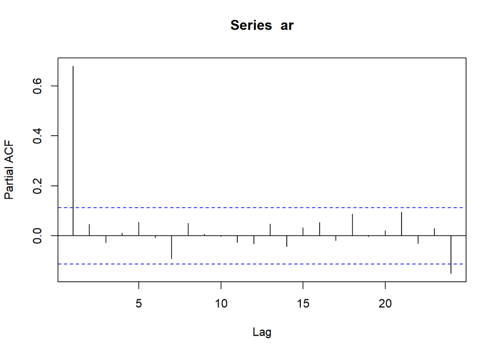

```r
pacf(ar)
```

Berdasarkan plot PACF tersebut, terlihat bahwa plot PACF *cuts off* pada lag pertama, sejalan dengan teori yang ada

# Plot EACF

```r
TSA::eacf(ar)
```

```
## AR/MA
##   0 1 2 3 4 5 6 7 8 9 10 11 12 13
## 0 x x x x x x o o o o o  o  o  o
## 1 o o o o o o o o o o o  o  o  o
## 2 x o o o o o o o o o o  o  o  o
## 3 x o o o o o o o o o o  o  o  o
## 4 x x o o o o o o o o o  o  o  o
## 5 x x x o o o o o o o o  o  o  o
## 6 x x o o x o o o o o o  o  o  o
## 7 x x x o x x o o o o o  o  o  o
```

Berdasarkan pola segitiga nol pada plot EACF, terlihat bahwa segitiga nol berada pada ordo AR(1) dan ordo MA(0)

# Scatterplot Antar Lag

## Korelasi antara $Y_t$ dengan $Y_{t-1}$

```r
#Yt
yt_ar <- ar[-1]
yt_ar
```

```
##   [1]  2.000000000  2.156793378  0.639597572  1.664793187  0.285364890
##   [6]  2.280835987  1.709126435  1.746343603  0.275649667  0.046093350
##  [11]  0.730795119 -0.613190266  0.874845940  0.176777701 -0.611191876
##  [16] -0.809176354 -0.503726170  0.994340360  2.031960854  0.277504861
##  [21] -0.657120352 -1.310598748  0.553765233 -0.789923176  0.078443836
##  [26]  0.141579335 -0.060460421  0.884878521  1.084959566  0.387960487
##  [31]  1.759367447  1.649494492  1.648984611  2.152770506 -0.082872853
##  [36] -0.372578181 -0.874740794 -0.963916843 -0.544359229 -1.589533399
##  [41] -1.311701739 -1.193691953 -1.139971186  0.467704865 -0.032228547
##  [46] -0.507793438 -0.642506093 -1.776296697 -2.029240305 -0.481542016
##  [51] -0.647914257 -1.631512919 -2.778307115 -1.398561780 -0.820693612
##  [56] -0.551935671  0.732488503 -1.592012808 -2.403071699 -0.416015850
##  [61] -0.999234301 -1.040885441 -0.267010440  0.857488135 -0.467838606
##  [66] -0.941395097 -0.547093774 -0.158100892 -0.862211248 -0.279847710
##  [71] -0.933154525 -0.545150610 -2.145791335 -1.412923390 -0.286906870
```

[output cut: 45 more lines]

```r
#Yt-1
yt_1_ar <- ar[-300]
yt_1_ar
```

```
##   [1]  1.000000000  2.000000000  2.156793378  0.639597572  1.664793187
##   [6]  0.285364890  2.280835987  1.709126435  1.746343603  0.275649667
##  [11]  0.046093350  0.730795119 -0.613190266  0.874845940  0.176777701
##  [16] -0.611191876 -0.809176354 -0.503726170  0.994340360  2.031960854
##  [21]  0.277504861 -0.657120352 -1.310598748  0.553765233 -0.789923176
##  [26]  0.078443836  0.141579335 -0.060460421  0.884878521  1.084959566
##  [31]  0.387960487  1.759367447  1.649494492  1.648984611  2.152770506
##  [36] -0.082872853 -0.372578181 -0.874740794 -0.963916843 -0.544359229
##  [41] -1.589533399 -1.311701739 -1.193691953 -1.139971186  0.467704865
##  [46] -0.032228547 -0.507793438 -0.642506093 -1.776296697 -2.029240305
##  [51] -0.481542016 -0.647914257 -1.631512919 -2.778307115 -1.398561780
##  [56] -0.820693612 -0.551935671  0.732488503 -1.592012808 -2.403071699
##  [61] -0.416015850 -0.999234301 -1.040885441 -0.267010440  0.857488135
##  [66] -0.467838606 -0.941395097 -0.547093774 -0.158100892 -0.862211248
##  [71] -0.279847710 -0.933154525 -0.545150610 -2.145791335 -1.412923390
```

[output cut: 45 more lines]

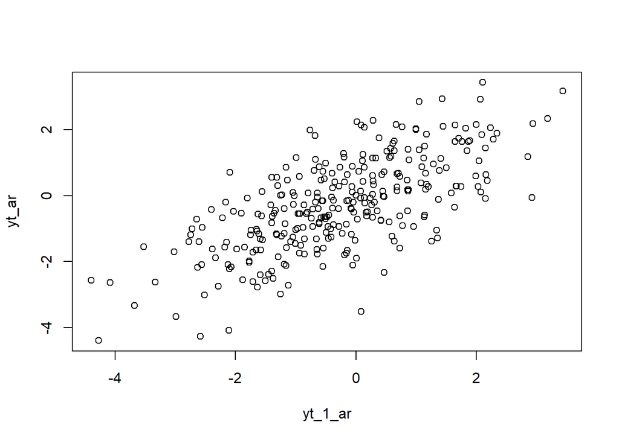

```r
plot(y=yt_ar,x=yt_1_ar)
```

Berdasarkan scatterplot tersebut, terlihat bahwa terdapat hubungan positif antara $Y_t$ dengan $Y_{t-1}$. Hal ini sesuai dengan teori yang ada.

```r
#Yt
yt_ar2 <- ar[-c(1,2)]
yt_ar2
```

```
##   [1]  2.156793378  0.639597572  1.664793187  0.285364890  2.280835987
##   [6]  1.709126435  1.746343603  0.275649667  0.046093350  0.730795119
##  [11] -0.613190266  0.874845940  0.176777701 -0.611191876 -0.809176354
##  [16] -0.503726170  0.994340360  2.031960854  0.277504861 -0.657120352
##  [21] -1.310598748  0.553765233 -0.789923176  0.078443836  0.141579335
##  [26] -0.060460421  0.884878521  1.084959566  0.387960487  1.759367447
##  [31]  1.649494492  1.648984611  2.152770506 -0.082872853 -0.372578181
##  [36] -0.874740794 -0.963916843 -0.544359229 -1.589533399 -1.311701739
##  [41] -1.193691953 -1.139971186  0.467704865 -0.032228547 -0.507793438
##  [46] -0.642506093 -1.776296697 -2.029240305 -0.481542016 -0.647914257
##  [51] -1.631512919 -2.778307115 -1.398561780 -0.820693612 -0.551935671
##  [56]  0.732488503 -1.592012808 -2.403071699 -0.416015850 -0.999234301
##  [61] -1.040885441 -0.267010440  0.857488135 -0.467838606 -0.941395097
##  [66] -0.547093774 -0.158100892 -0.862211248 -0.279847710 -0.933154525
##  [71] -0.545150610 -2.145791335 -1.412923390 -0.286906870 -0.387240012
```

[output cut: 45 more lines]

```r
#Yt-2
yt_2_ar <- ar[-c(299,300)]
yt_2_ar
```

```
##   [1]  1.000000000  2.000000000  2.156793378  0.639597572  1.664793187
##   [6]  0.285364890  2.280835987  1.709126435  1.746343603  0.275649667
##  [11]  0.046093350  0.730795119 -0.613190266  0.874845940  0.176777701
##  [16] -0.611191876 -0.809176354 -0.503726170  0.994340360  2.031960854
##  [21]  0.277504861 -0.657120352 -1.310598748  0.553765233 -0.789923176
##  [26]  0.078443836  0.141579335 -0.060460421  0.884878521  1.084959566
##  [31]  0.387960487  1.759367447  1.649494492  1.648984611  2.152770506
##  [36] -0.082872853 -0.372578181 -0.874740794 -0.963916843 -0.544359229
##  [41] -1.589533399 -1.311701739 -1.193691953 -1.139971186  0.467704865
##  [46] -0.032228547 -0.507793438 -0.642506093 -1.776296697 -2.029240305
##  [51] -0.481542016 -0.647914257 -1.631512919 -2.778307115 -1.398561780
##  [56] -0.820693612 -0.551935671  0.732488503 -1.592012808 -2.403071699
##  [61] -0.416015850 -0.999234301 -1.040885441 -0.267010440  0.857488135
##  [66] -0.467838606 -0.941395097 -0.547093774 -0.158100892 -0.862211248
##  [71] -0.279847710 -0.933154525 -0.545150610 -2.145791335 -1.412923390
```

[output cut: 45 more lines]

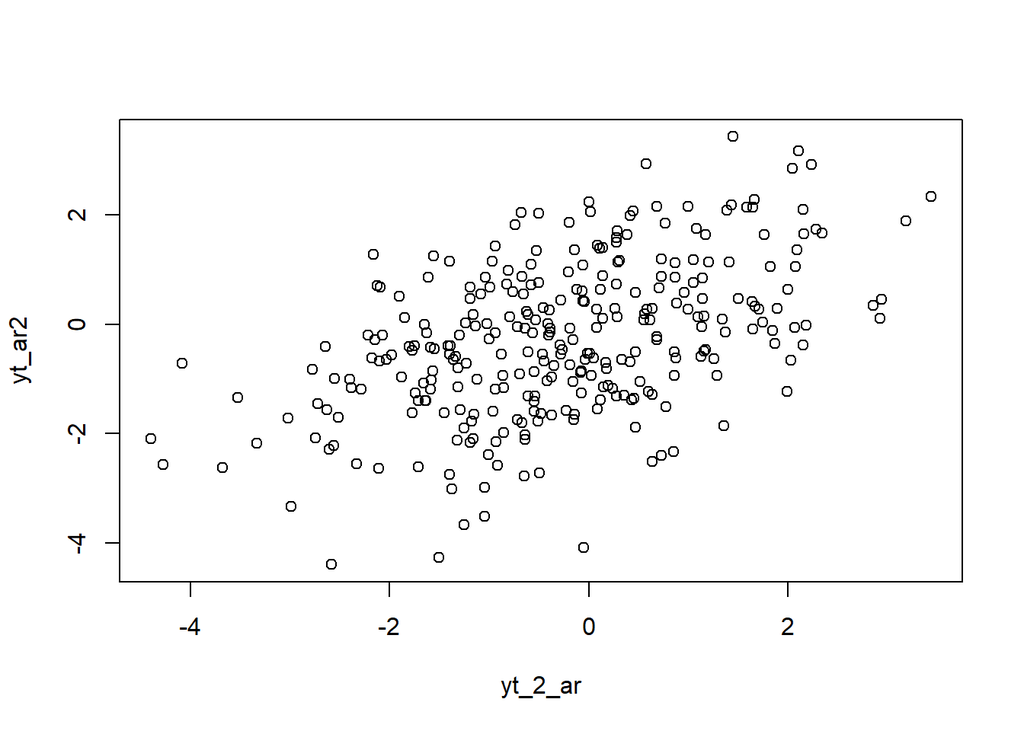

```r
plot(y=yt_ar2,x=yt_2_ar)
```

```r
#Yt
yt_ar3 <- ar[-c(1,2,3)]
yt_ar3
```

```
##   [1]  0.639597572  1.664793187  0.285364890  2.280835987  1.709126435
##   [6]  1.746343603  0.275649667  0.046093350  0.730795119 -0.613190266
##  [11]  0.874845940  0.176777701 -0.611191876 -0.809176354 -0.503726170
##  [16]  0.994340360  2.031960854  0.277504861 -0.657120352 -1.310598748
##  [21]  0.553765233 -0.789923176  0.078443836  0.141579335 -0.060460421
##  [26]  0.884878521  1.084959566  0.387960487  1.759367447  1.649494492
##  [31]  1.648984611  2.152770506 -0.082872853 -0.372578181 -0.874740794
##  [36] -0.963916843 -0.544359229 -1.589533399 -1.311701739 -1.193691953
##  [41] -1.139971186  0.467704865 -0.032228547 -0.507793438 -0.642506093
##  [46] -1.776296697 -2.029240305 -0.481542016 -0.647914257 -1.631512919
##  [51] -2.778307115 -1.398561780 -0.820693612 -0.551935671  0.732488503
##  [56] -1.592012808 -2.403071699 -0.416015850 -0.999234301 -1.040885441
##  [61] -0.267010440  0.857488135 -0.467838606 -0.941395097 -0.547093774
##  [66] -0.158100892 -0.862211248 -0.279847710 -0.933154525 -0.545150610
##  [71] -2.145791335 -1.412923390 -0.286906870 -0.387240012 -0.371845498
```

[output cut: 45 more lines]

```r
#Yt-3
yt_3_ar <- ar[-c(298,299,300)]
yt_3_ar
```

```
##   [1]  1.000000000  2.000000000  2.156793378  0.639597572  1.664793187
##   [6]  0.285364890  2.280835987  1.709126435  1.746343603  0.275649667
##  [11]  0.046093350  0.730795119 -0.613190266  0.874845940  0.176777701
##  [16] -0.611191876 -0.809176354 -0.503726170  0.994340360  2.031960854
##  [21]  0.277504861 -0.657120352 -1.310598748  0.553765233 -0.789923176
##  [26]  0.078443836  0.141579335 -0.060460421  0.884878521  1.084959566
##  [31]  0.387960487  1.759367447  1.649494492  1.648984611  2.152770506
##  [36] -0.082872853 -0.372578181 -0.874740794 -0.963916843 -0.544359229
##  [41] -1.589533399 -1.311701739 -1.193691953 -1.139971186  0.467704865
##  [46] -0.032228547 -0.507793438 -0.642506093 -1.776296697 -2.029240305
##  [51] -0.481542016 -0.647914257 -1.631512919 -2.778307115 -1.398561780
##  [56] -0.820693612 -0.551935671  0.732488503 -1.592012808 -2.403071699
##  [61] -0.416015850 -0.999234301 -1.040885441 -0.267010440  0.857488135
##  [66] -0.467838606 -0.941395097 -0.547093774 -0.158100892 -0.862211248
##  [71] -0.279847710 -0.933154525 -0.545150610 -2.145791335 -1.412923390
```

[output cut: 45 more lines]

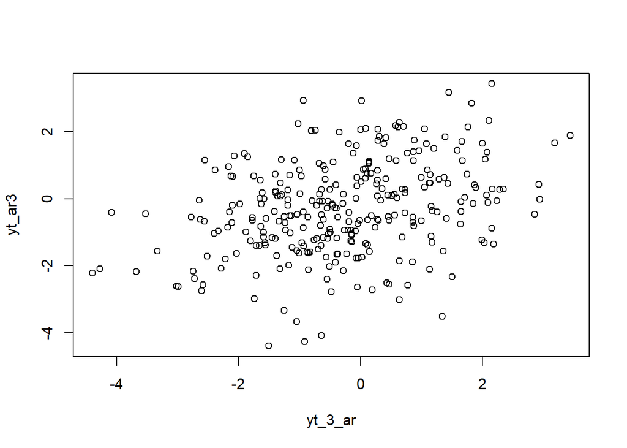

```r
plot(y=yt_ar3,x=yt_3_ar)
```

```r
cor(yt_ar,yt_1_ar)
```

```
## [1] 0.6835815
```

```r
cor(yt_ar2,yt_2_ar)
```

```
## [1] 0.4914143
```

```r
cor(yt_ar3,yt_3_ar)
```

```
## [1] 0.3363363
```

## Nomor (3) ARMA(2,2)

```r
arma.sim <- function(n, macoef, arcoef){
  manum <- length(macoef)
  arnum <- length(arcoef)
  stopifnot(manum < n & arnum < n)

  wn <- rnorm(n, sd = 0.5)
  init <- max(manum, arnum)

  arma <- wn[1:init]
  for(i in {init+1}:n){
   mastart <- i - manum
   maend <- i-1
   arstart <- i - arnum
   arend <- i-1
   arma[i] <- sum(arcoef * arma[arstart:arend]) + sum(macoef * wn[mastart:maend])  + wn[i]
   }
  return(arma)
}
```

```r
arma22 <- arma.sim(300, c(0.4, 0.6), c(0.5,0.2))

arma22 |> arima(c(2,0,2))
```

```
##
## Call:
## arima(x = arma22, order = c(2, 0, 2))
##
## Coefficients:
##          ar1     ar2     ma1     ma2  intercept
##       0.1329  0.5509  0.6838  0.4110     0.1503
## s.e.  0.0805  0.0793  0.0815  0.0632     0.1844
##
## sigma^2 estimated as 0.2396:  log likelihood = -212.37,  aic = 436.75
```

# Menggunakan Rumus Manual

$$y_{t} = e_t + 0.5Y_{t-1}+0.2Y_{t-2}+0.4e_{t-1}+0.6e_{t-2}$$

```r
phi1 = 0.5
theta1 = 0.4
phi2 = 0.2
theta2 = 0.6
y.arma=c(1:n)
for (i in 3:n){
  y.arma[i] = phi2*y.arma[i-2]+theta2*wn[i-2]+phi1*y.arma[i-1] + theta1*wn[i-1]+wn[i]
}

y.arma
```

```
##   [1]  1.00000000  2.00000000  1.25190764  0.83549583  1.82032155  0.26448354
##   [7]  2.57970193  2.17149037  3.32506989  1.63871215  0.92899879  0.70485180
##  [13] -0.45313355  0.94613414  0.06586207 -0.08642571 -1.00160069 -1.23528944
##  [19]  0.27595244  2.10352995  1.66864942  0.65914984 -1.41754691 -0.37282960
##  [25] -1.36093848  0.09003601 -0.30457831  0.04050744  0.94356061  1.40104801
##  [31]  1.35166180  2.56460523  2.58531476  3.36386695  3.80165248  1.76731465
##  [37]  0.88569753 -1.07367680 -1.53749807 -1.45487565 -2.38570740 -2.27419178
##  [43] -2.67213930 -2.40450454 -0.70452587 -0.52914996 -0.24007768 -0.86497260
##  [49] -2.33798435 -3.12526962 -2.35902147 -2.05807930 -2.17960692 -3.81966319
##  [55] -3.48879417 -3.04710396 -1.71935123  0.01929727 -1.63017942 -2.60038418
##  [61] -2.33245257 -2.60748393 -1.69018888 -1.28290535  0.12615258 -0.28504971
##  [67] -0.61403773 -1.20435503 -0.94177550 -1.25370790 -0.71959277 -1.56242038
##  [73] -1.08632106 -2.92374430 -2.59833030 -2.13955103 -1.34975680 -0.69888563
##  [79] -0.52636326 -1.94013222 -2.39664809 -2.73582356 -2.81573446 -0.64910785
##  [85]  0.54227848  0.99240521  0.27499507 -1.20298595 -3.47159886 -2.77096007
```

[output cut: 35 more lines]

# Karakteristik ARMA(2,2)

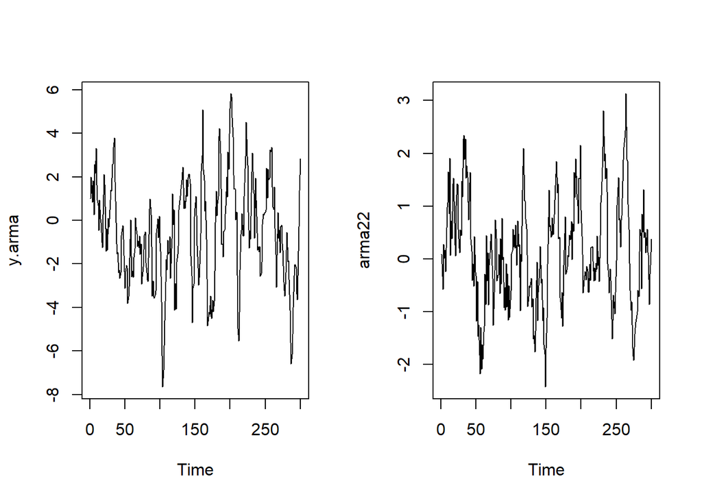

```r
par(mfrow = c(1, 2))
ts.plot(y.arma)
ts.plot(arma22)
```

Berdasarkan plot time series tersebut, terlihat bahwa model ARMA(2,2) cenderung stasioner dalam rataan

# Plot PACF

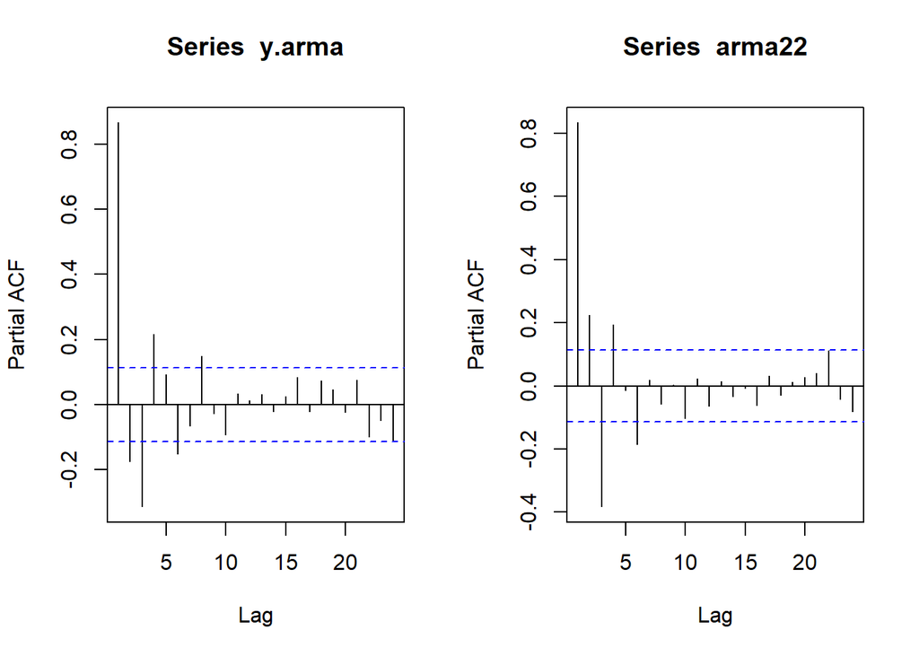

```r
par(mfrow = c(1, 2))
pacf(y.arma)
pacf(arma22)
```

# Plot EACF

```r
TSA::eacf(y.arma)
```

```
## AR/MA
##   0 1 2 3 4 5 6 7 8 9 10 11 12 13
## 0 x x x x x x x o o o o  o  o  o
## 1 x x o o o o o o o o o  o  o  o
## 2 x x o o o o o o o o o  o  o  o
## 3 x x o o o o o o o o o  o  o  o
## 4 x x o o x o o o o o o  o  o  o
## 5 x x o x o o o o o o o  o  o  o
## 6 x x x x x o x o o o o  o  o  o
## 7 x x o x x o x x o o o  o  o  o
```

```r
TSA::eacf(arma22)
```

```
## AR/MA
##   0 1 2 3 4 5 6 7 8 9 10 11 12 13
## 0 x x x x x x x o o o o  x  x  x
## 1 x x x x o x o o o o o  x  o  x
## 2 x x o x o x o o o o o  x  o  o
## 3 x x o o o x o o o o o  o  o  o
## 4 o x x x o o o o o o o  o  o  o
## 5 o x x x o x o o o o o  o  o  o
## 6 o x o x o o o o o o o  o  o  o
## 7 x x o x o o o o o o o  o  o  o
```

# Scatter Antar Lag

```r
#Yt
yt_arma1 <- arma22[-1]
yt_arma1
```

```
##   [1] -0.088466350 -0.576567816  0.273902188  0.010397555  0.160917521
##   [6] -0.239638592  0.203326613  0.973670174  1.070246054  1.652056876
##  [11]  0.856027104  1.904410928  0.066167296  0.722621546  0.383923563
##  [16]  1.417989691  1.528081972  1.099761542  0.260559971  0.055704034
##  [21]  1.003776796  1.424734487  1.412442419  0.562151060  0.203955823
##  [26]  0.113811297  0.554899745  0.439623188  1.472156359  1.175930234
##  [31]  2.276130503  2.344849951  1.882772177  2.273713104  1.534337260
##  [36]  1.770750027  1.548293469  1.075769866  0.742582817  1.436425446
##  [41]  1.643266813  0.373364076  0.148621935 -0.406564454 -0.092116234
##  [46] -0.521648465  0.417795683 -0.246136469 -0.315970413 -1.179949123
##  [51] -0.429831447 -1.468412390 -1.249333645 -1.819340028 -2.179588377
##  [56] -1.303116921 -2.087719415 -1.625726329 -1.900298511 -1.388282778
##  [61] -1.274747498 -0.294375206 -0.859361746  0.442171357 -0.423189706
##  [66]  0.116721094 -0.869597994 -0.121992981  0.112696624  0.330783986
##  [71]  0.467629581 -0.117690364 -0.373023191 -1.256528538 -0.639913263
```

[output cut: 45 more lines]

```r
#Yt-1
yt_1_arma <- arma22[-300]
yt_1_arma
```

```
##   [1]  0.090124352 -0.088466350 -0.576567816  0.273902188  0.010397555
##   [6]  0.160917521 -0.239638592  0.203326613  0.973670174  1.070246054
##  [11]  1.652056876  0.856027104  1.904410928  0.066167296  0.722621546
##  [16]  0.383923563  1.417989691  1.528081972  1.099761542  0.260559971
##  [21]  0.055704034  1.003776796  1.424734487  1.412442419  0.562151060
##  [26]  0.203955823  0.113811297  0.554899745  0.439623188  1.472156359
##  [31]  1.175930234  2.276130503  2.344849951  1.882772177  2.273713104
##  [36]  1.534337260  1.770750027  1.548293469  1.075769866  0.742582817
##  [41]  1.436425446  1.643266813  0.373364076  0.148621935 -0.406564454
##  [46] -0.092116234 -0.521648465  0.417795683 -0.246136469 -0.315970413
##  [51] -1.179949123 -0.429831447 -1.468412390 -1.249333645 -1.819340028
##  [56] -2.179588377 -1.303116921 -2.087719415 -1.625726329 -1.900298511
##  [61] -1.388282778 -1.274747498 -0.294375206 -0.859361746  0.442171357
##  [66] -0.423189706  0.116721094 -0.869597994 -0.121992981  0.112696624
##  [71]  0.330783986  0.467629581 -0.117690364 -0.373023191 -1.256528538
```

[output cut: 45 more lines]

```r
#Yt
yt_arma2 <- arma22[-c(1,2)]
yt_arma2
```

```
##   [1] -0.576567816  0.273902188  0.010397555  0.160917521 -0.239638592
##   [6]  0.203326613  0.973670174  1.070246054  1.652056876  0.856027104
##  [11]  1.904410928  0.066167296  0.722621546  0.383923563  1.417989691
##  [16]  1.528081972  1.099761542  0.260559971  0.055704034  1.003776796
##  [21]  1.424734487  1.412442419  0.562151060  0.203955823  0.113811297
##  [26]  0.554899745  0.439623188  1.472156359  1.175930234  2.276130503
##  [31]  2.344849951  1.882772177  2.273713104  1.534337260  1.770750027
##  [36]  1.548293469  1.075769866  0.742582817  1.436425446  1.643266813
##  [41]  0.373364076  0.148621935 -0.406564454 -0.092116234 -0.521648465
##  [46]  0.417795683 -0.246136469 -0.315970413 -1.179949123 -0.429831447
##  [51] -1.468412390 -1.249333645 -1.819340028 -2.179588377 -1.303116921
##  [56] -2.087719415 -1.625726329 -1.900298511 -1.388282778 -1.274747498
##  [61] -0.294375206 -0.859361746  0.442171357 -0.423189706  0.116721094
##  [66] -0.869597994 -0.121992981  0.112696624  0.330783986  0.467629581
##  [71] -0.117690364 -0.373023191 -1.256528538 -0.639913263 -0.223392792
```

[output cut: 45 more lines]

```r
#Yt-1
yt_2_arma <- arma22[-c(299,300)]
yt_2_arma
```

```
##   [1]  0.090124352 -0.088466350 -0.576567816  0.273902188  0.010397555
##   [6]  0.160917521 -0.239638592  0.203326613  0.973670174  1.070246054
##  [11]  1.652056876  0.856027104  1.904410928  0.066167296  0.722621546
##  [16]  0.383923563  1.417989691  1.528081972  1.099761542  0.260559971
##  [21]  0.055704034  1.003776796  1.424734487  1.412442419  0.562151060
##  [26]  0.203955823  0.113811297  0.554899745  0.439623188  1.472156359
##  [31]  1.175930234  2.276130503  2.344849951  1.882772177  2.273713104
##  [36]  1.534337260  1.770750027  1.548293469  1.075769866  0.742582817
##  [41]  1.436425446  1.643266813  0.373364076  0.148621935 -0.406564454
##  [46] -0.092116234 -0.521648465  0.417795683 -0.246136469 -0.315970413
##  [51] -1.179949123 -0.429831447 -1.468412390 -1.249333645 -1.819340028
##  [56] -2.179588377 -1.303116921 -2.087719415 -1.625726329 -1.900298511
##  [61] -1.388282778 -1.274747498 -0.294375206 -0.859361746  0.442171357
##  [66] -0.423189706  0.116721094 -0.869597994 -0.121992981  0.112696624
##  [71]  0.330783986  0.467629581 -0.117690364 -0.373023191 -1.256528538
```

[output cut: 45 more lines]

```r
#Yt
yt_arma3 <- arma22[-c(1,2,3)]
yt_arma3
```

```
##   [1]  0.273902188  0.010397555  0.160917521 -0.239638592  0.203326613
##   [6]  0.973670174  1.070246054  1.652056876  0.856027104  1.904410928
##  [11]  0.066167296  0.722621546  0.383923563  1.417989691  1.528081972
##  [16]  1.099761542  0.260559971  0.055704034  1.003776796  1.424734487
##  [21]  1.412442419  0.562151060  0.203955823  0.113811297  0.554899745
##  [26]  0.439623188  1.472156359  1.175930234  2.276130503  2.344849951
##  [31]  1.882772177  2.273713104  1.534337260  1.770750027  1.548293469
##  [36]  1.075769866  0.742582817  1.436425446  1.643266813  0.373364076
##  [41]  0.148621935 -0.406564454 -0.092116234 -0.521648465  0.417795683
##  [46] -0.246136469 -0.315970413 -1.179949123 -0.429831447 -1.468412390
##  [51] -1.249333645 -1.819340028 -2.179588377 -1.303116921 -2.087719415
##  [56] -1.625726329 -1.900298511 -1.388282778 -1.274747498 -0.294375206
##  [61] -0.859361746  0.442171357 -0.423189706  0.116721094 -0.869597994
##  [66] -0.121992981  0.112696624  0.330783986  0.467629581 -0.117690364
##  [71] -0.373023191 -1.256528538 -0.639913263 -0.223392792  0.740017096
```

[output cut: 45 more lines]

```r
#Yt-3
yt_3_arma <- arma22[-c(298,299,300)]
yt_3_arma
```

```
##   [1]  0.090124352 -0.088466350 -0.576567816  0.273902188  0.010397555
##   [6]  0.160917521 -0.239638592  0.203326613  0.973670174  1.070246054
##  [11]  1.652056876  0.856027104  1.904410928  0.066167296  0.722621546
##  [16]  0.383923563  1.417989691  1.528081972  1.099761542  0.260559971
##  [21]  0.055704034  1.003776796  1.424734487  1.412442419  0.562151060
##  [26]  0.203955823  0.113811297  0.554899745  0.439623188  1.472156359
##  [31]  1.175930234  2.276130503  2.344849951  1.882772177  2.273713104
##  [36]  1.534337260  1.770750027  1.548293469  1.075769866  0.742582817
##  [41]  1.436425446  1.643266813  0.373364076  0.148621935 -0.406564454
##  [46] -0.092116234 -0.521648465  0.417795683 -0.246136469 -0.315970413
##  [51] -1.179949123 -0.429831447 -1.468412390 -1.249333645 -1.819340028
##  [56] -2.179588377 -1.303116921 -2.087719415 -1.625726329 -1.900298511
##  [61] -1.388282778 -1.274747498 -0.294375206 -0.859361746  0.442171357
##  [66] -0.423189706  0.116721094 -0.869597994 -0.121992981  0.112696624
##  [71]  0.330783986  0.467629581 -0.117690364 -0.373023191 -1.256528538
```

[output cut: 45 more lines]

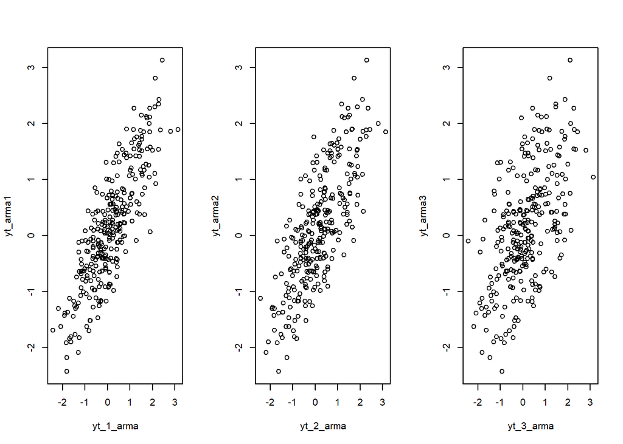

```r
par(mfrow = c(1, 3))
plot(y=yt_arma1,x=yt_1_arma)
plot(y=yt_arma2,x=yt_2_arma)
plot(y=yt_arma3,x=yt_3_arma)
```

```r
cor(yt_arma1,yt_1_arma)
```

```
## [1] 0.8339107
```

```r
cor(yt_arma2,yt_2_arma)
```

```
## [1] 0.7637866
```

```r
cor(yt_arma3,yt_3_arma)
```

```
## [1] 0.5710032
```